# Responses to Assignment 2

# About File

1. You are supposed to submit R Notebook File with a file name a2_YourID.nb.html.
- Some submitted a2_YourID.html. You need to create R Notebook. Use the template in Moodle.
- Some did not run each code chunk. You should run each code or select Run all under Run button. If some code chunk has a problem or an error, run each code chunk or use Run all chunk above or Run all chunk below, so the result appear in your R Notebook file.
2. You are supposed to write observations.
- Writing codes seem to be the main, however, we are learning ‘data analysis’ not ‘prgramming’. Do not forget to write explanation of the data, questions and observations.
3. Cheatsheet, Posit Primers, and the textbook ‘R for Data Science’ are the first reference you should look at together wih my lecture materials.

# Set up

```r
library(tidyverse)
library(gapminder)
```

```r
(df <- gapminder)
```

| country | continent | year | lifeExp | pop | gdpPercap |
| --- | --- | --- | --- | --- | --- |
| Afghanistan | Asia | 1952 | 28.80100 | 8425333 | 779.4453 |
| Afghanistan | Asia | 1957 | 30.33200 | 9240934 | 820.8530 |
| Afghanistan | Asia | 1962 | 31.99700 | 10267083 | 853.1007 |
| Afghanistan | Asia | 1967 | 34.02000 | 11537966 | 836.1971 |
| Afghanistan | Asia | 1972 | 36.08800 | 13079460 | 739.9811 |
| Afghanistan | Asia | 1977 | 38.43800 | 14880372 | 786.1134 |
| Afghanistan | Asia | 1982 | 39.85400 | 12881816 | 978.0114 |
| Afghanistan | Asia | 1987 | 40.82200 | 13867957 | 852.3959 |
| Afghanistan | Asia | 1992 | 41.67400 | 16317921 | 649.3414 |
| Afghanistan | Asia | 1997 | 41.76300 | 22227415 | 635.3414 |

[output cut: 990 more lines]

# General Comments

## Varibles

We need to know about the variables. At least you must know if the variable is a categorical variable or a numerical variable.

### Example: `datasets::CO2`

You can obtain basic infomation of the data by the following code:

```r
help(CO2) # or ? CO2
```

- **Description**: The CO2 data frame has 84 rows and 5 columns of data from an experiment on the cold tolerance of the grass species Echinochloa crus-galli.
- **Usage**: CO2
- **Format**
  - An object of class c(“nfnGroupedData”, “nfGroupedData”, “groupedData”, “data.frame”) containing the following columns:
  - Plant: an ordered factor with levels Qn1 < Qn2 < Qn3 < … < Mc1 giving a unique identifier for each plant.
  - Type: a factor with levels Quebec Mississippi giving the origin of the plant
  - Treatment: a factor with levels nonchilled chilled
  - conc: a numeric vector of ambient carbon dioxide concentrations (mL/L).
  - uptake: a numeric vector of carbon dioxide uptake rates (/m^2μmol/m 2 sec).
- **Details**: The CO_2 uptake of six plants from Quebec and six plants from Mississippi was measured at several levels of ambient CO_2 concentration. Half the plants of each type were chilled overnight before the experiment was conducted.
  - This dataset was originally part of package nlme, and that has methods (including for [, as.data.frame, plot and print) for its grouped-data classes.
- **Source**: Potvin, C., Lechowicz, M. J. and Tardif, S. (1990) “The statistical analysis of ecophysiological response curves obtained from experiments involving repeated measures”, Ecology, 71, 1389–1400.
  - Pinheiro, J. C. and Bates, D. M. (2000) Mixed-effects Models in S and S-PLUS, Springer.

```r
df_co2 <- as_tibble(datasets::CO2)
df_co2
```

| Plant | Type | Treatment | conc | uptake |
| --- | --- | --- | --- | --- |
| Qn1 | Quebec | nonchilled | 95 | 16.0 |
| Qn1 | Quebec | nonchilled | 175 | 30.4 |
| Qn1 | Quebec | nonchilled | 250 | 34.8 |
| Qn1 | Quebec | nonchilled | 350 | 37.2 |
| Qn1 | Quebec | nonchilled | 500 | 35.3 |
| Qn1 | Quebec | nonchilled | 675 | 39.2 |
| Qn1 | Quebec | nonchilled | 1000 | 39.7 |
| Qn2 | Quebec | nonchilled | 95 | 13.6 |
| Qn2 | Quebec | nonchilled | 175 | 27.3 |
| Qn2 | Quebec | nonchilled | 250 | 37.1 |

[output cut: 74 more lines]

```r
glimpse(df_co2)
```

```
Rows: 84
Columns: 5
$ Plant     <ord> Qn1, Qn1, Qn1, Qn1, Qn1, Qn1, Qn1, Qn2, Qn2, Qn2, Qn2, Qn2, Qn2, Qn2, Qn3, Qn…
$ Type      <fct> Quebec, Quebec, Quebec, Quebec, Quebec, Quebec, Quebec, Quebec, Quebec, Quebe…
$ Treatment <fct> nonchilled, nonchilled, nonchilled, nonchilled, nonchilled, nonchilled, nonch…
$ conc      <dbl> 95, 175, 250, 350, 500, 675, 1000, 95, 175, 250, 350, 500, 675, 1000, 95, 175…
$ uptake    <dbl> 16.0, 30.4, 34.8, 37.2, 35.3, 39.2, 39.7, 13.6, 27.3, 37.1, 41.8, 40.6, 41.4,…
```

“factor” is a categorical data, and “double” is a numerical data.

```r
class(df_co2$Plant)
```

```
[1] "ordered" "factor"
```

```r
class(df_co2$Type)
```

```
[1] "factor"
```

```r
class(df_co2$Treatment)
```

```
[1] "factor"
```

```r
class(df_co2$conc)
```

```
[1] "numeric"
```

```r
class(df_co2$uptake)
```

```
[1] "numeric"
```

```r
summary(df_co2)
```

```
     Plant             Type         Treatment       conc          uptake
 Qn1    : 7   Quebec     :42   nonchilled:42   Min.   :  95   Min.   : 7.70
 Qn2    : 7   Mississippi:42   chilled   :42   1st Qu.: 175   1st Qu.:17.90
 Qn3    : 7                                    Median : 350   Median :28.30
 Qc1    : 7                                    Mean   : 435   Mean   :27.21
 Qc3    : 7                                    3rd Qu.: 675   3rd Qu.:37.12
 Qc2    : 7                                    Max.   :1000   Max.   :45.50
 (Other):42
```

#### Bar Plots

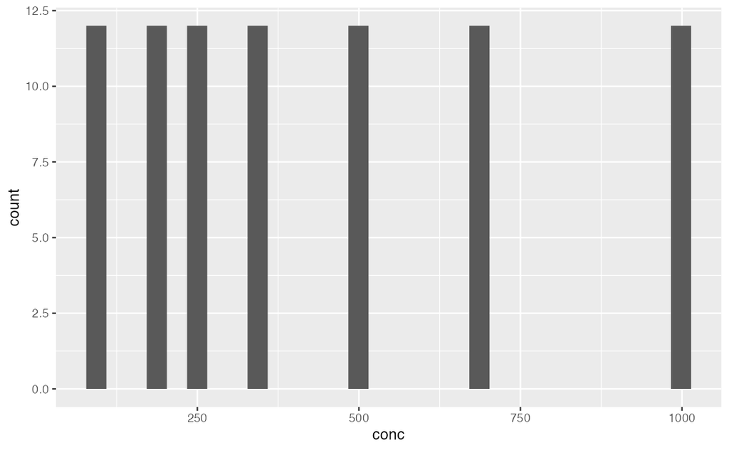

```r
df_co2 %>% ggplot(aes(x = conc)) + geom_histogram()
```

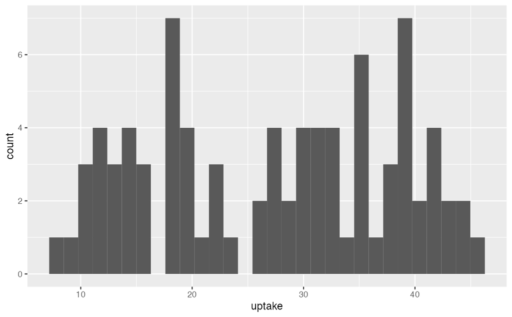

```r
df_co2 %>% ggplot(aes(x = uptake)) + geom_histogram()
```

#### Box Plots

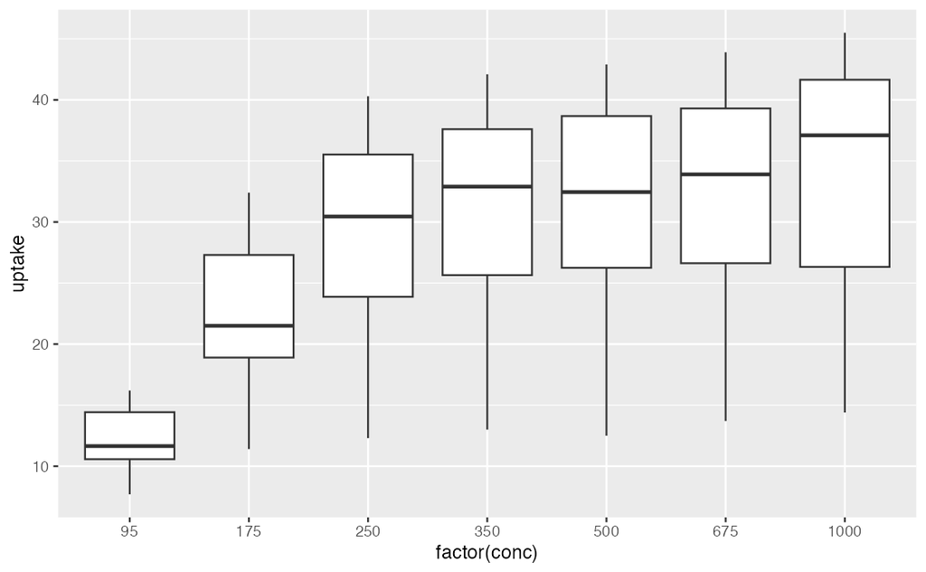

```r
df_co2 %>% ggplot(aes(x = factor(conc), y = uptake)) + geom_boxplot()
```

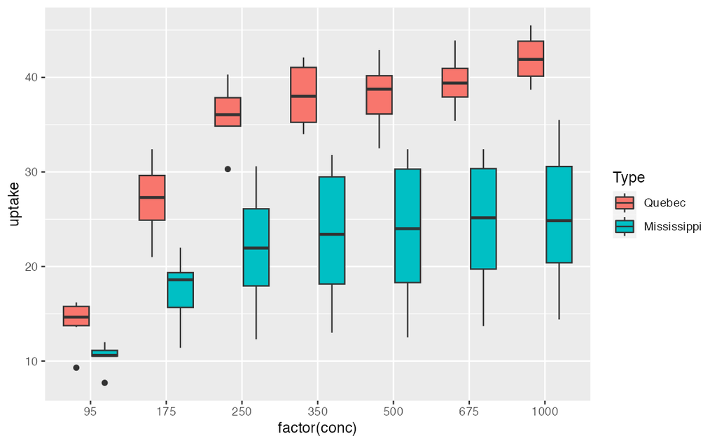

```r
df_co2 %>% ggplot(aes(x = factor(conc), y = uptake, fill = Type)) + geom_boxplot()
```

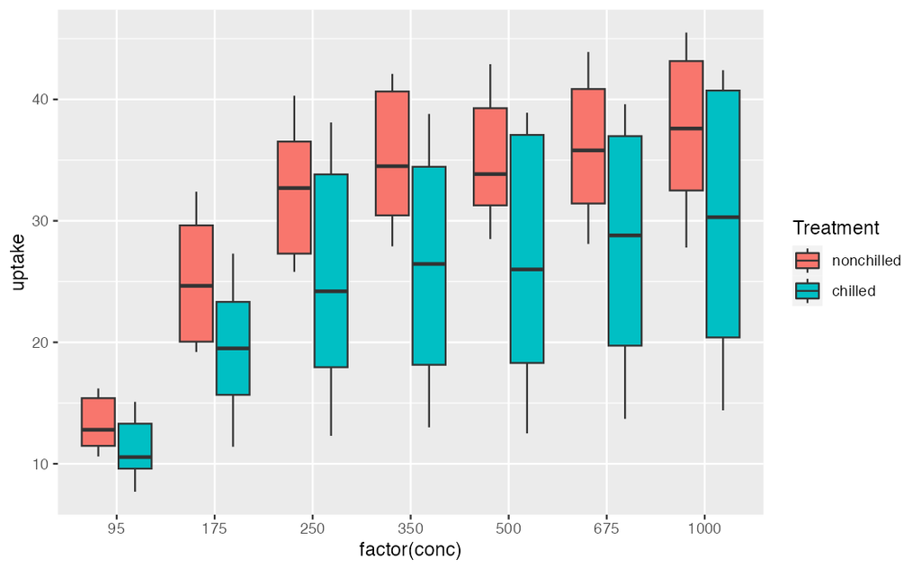

```r
df_co2 %>% ggplot(aes(x = factor(conc), y = uptake, fill = Treatment)) + geom_boxplot()
```

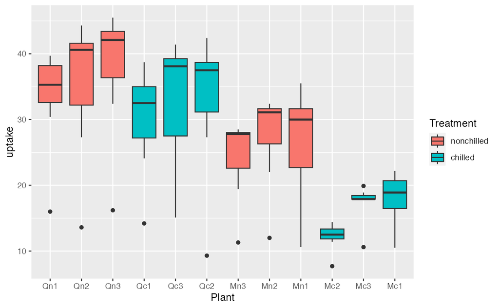

```r
df_co2 %>% ggplot(aes(x = Plant, y = uptake, fill = Treatment)) + geom_boxplot()
```

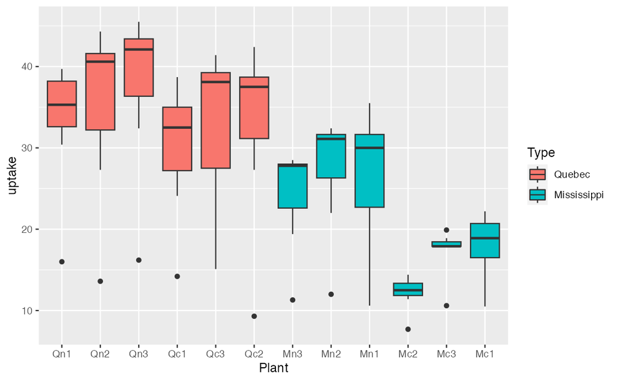

```r
df_co2 %>% ggplot(aes(x = Plant, y = uptake, fill = Type)) + geom_boxplot()
```

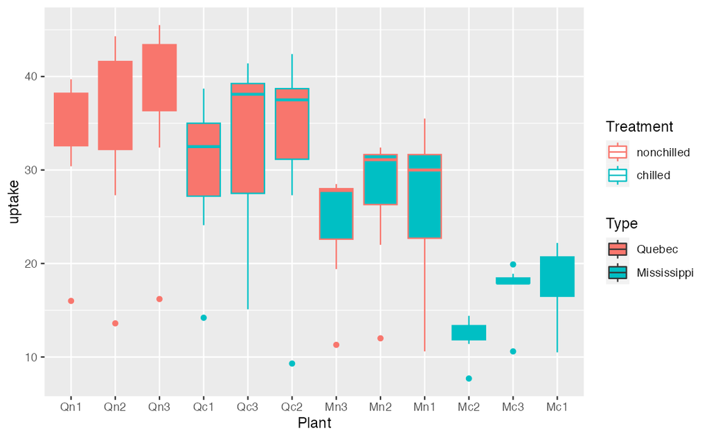

```r
df_co2 %>% ggplot(aes(x = Plant, y = uptake, fill = Type, color = Treatment)) + geom_boxplot()
```

#### Scatter Plots

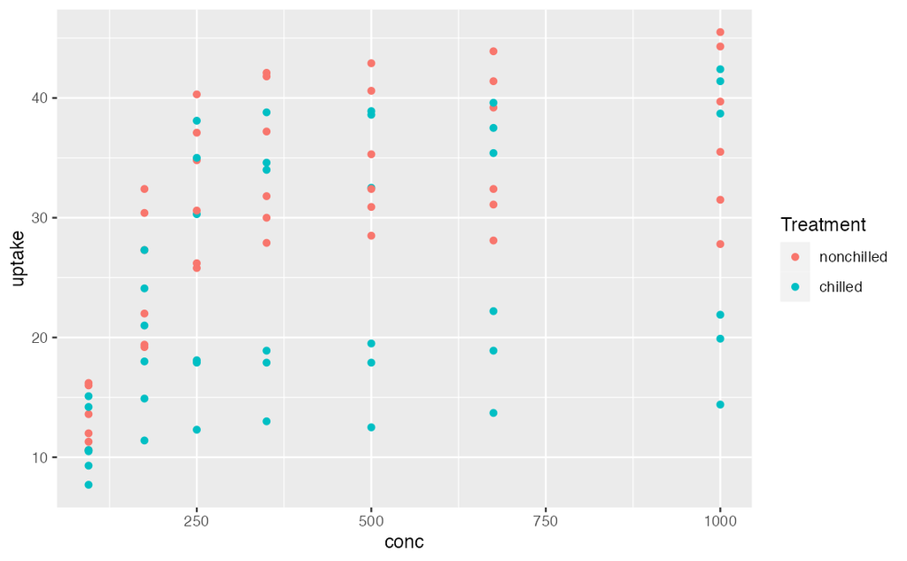

```r
df_co2 %>% ggplot(aes(x = conc, y = uptake, color = Treatment)) + geom_point()
```

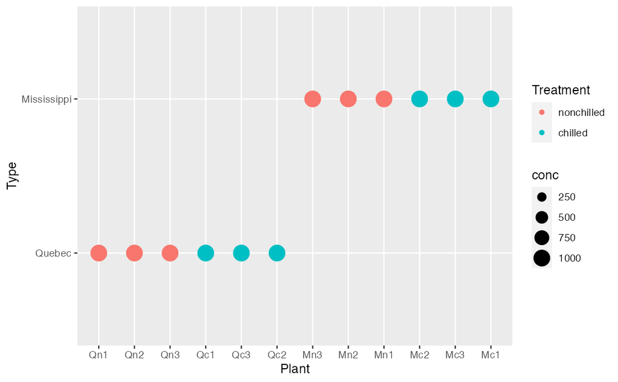

```r
df_co2 %>% ggplot(aes(x = Plant, y = Type, color = Treatment, size = conc)) + geom_point()
```

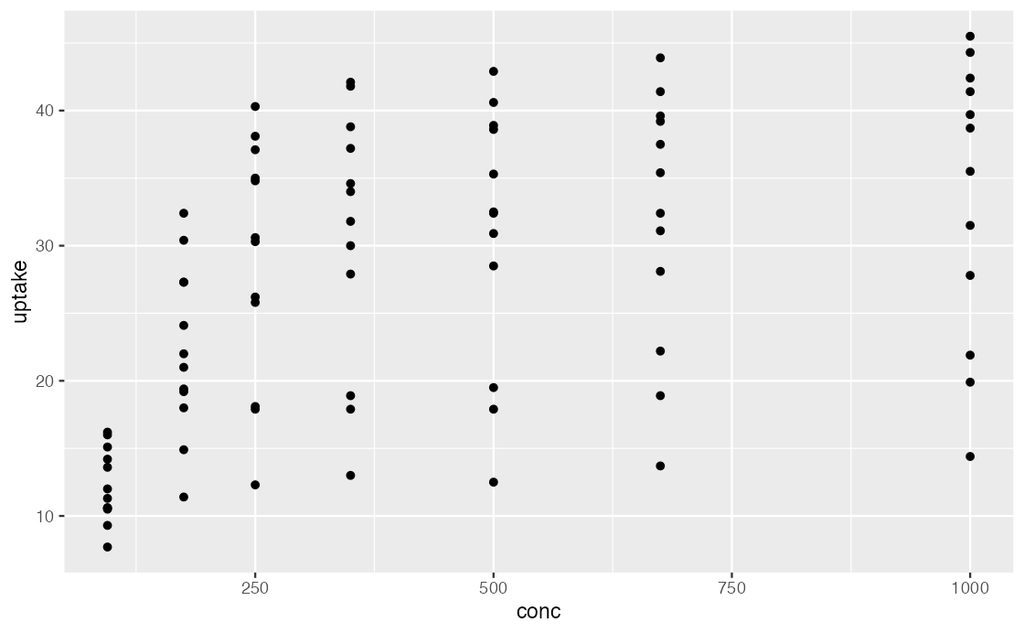

```r
ggplot(data = CO2) +
  geom_point(aes(x = conc, y = uptake))
```

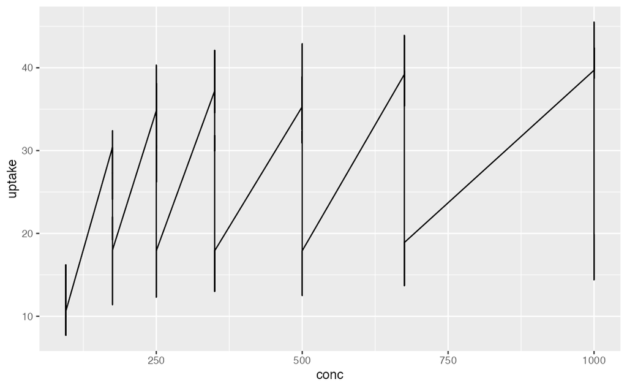

```r
ggplot(data = CO2) +
  geom_line(aes(x = conc, y = uptake))
```

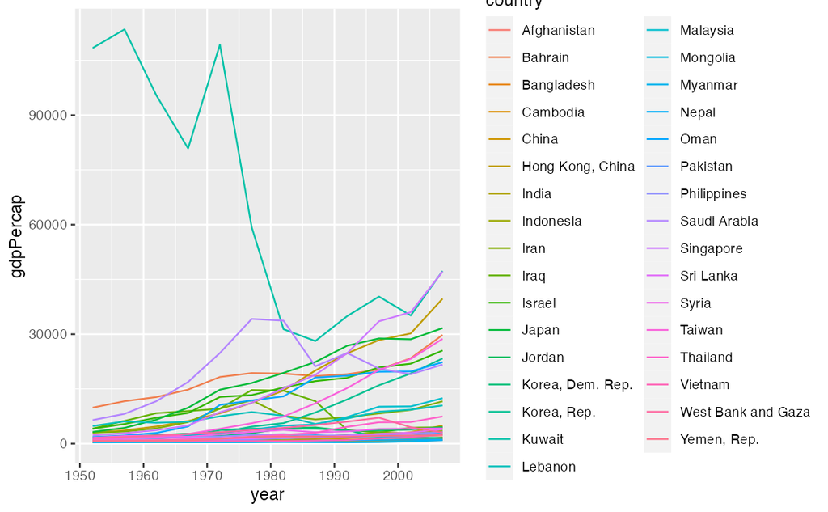

```r
df %>% filter(continent == "Asia") %>%
  ggplot(aes(x = year, y = gdpPercap, color = country)) + geom_line()
```

Appropriate graph?

```r
head(Seatbelts)
```

```
     DriversKilled drivers front rear   kms PetrolPrice VanKilled law
[1,]           107    1687   867  269  9059   0.1029718        12   0
[2,]            97    1508   825  265  7685   0.1023630         6   0
[3,]           102    1507   806  319  9963   0.1020625        12   0
[4,]            87    1385   814  407 10955   0.1008733         8   0
[5,]           119    1632   991  454 11823   0.1010197        10   0
[6,]           106    1511   945  427 12391   0.1005812        13   0
```

```
gapminder = df
```

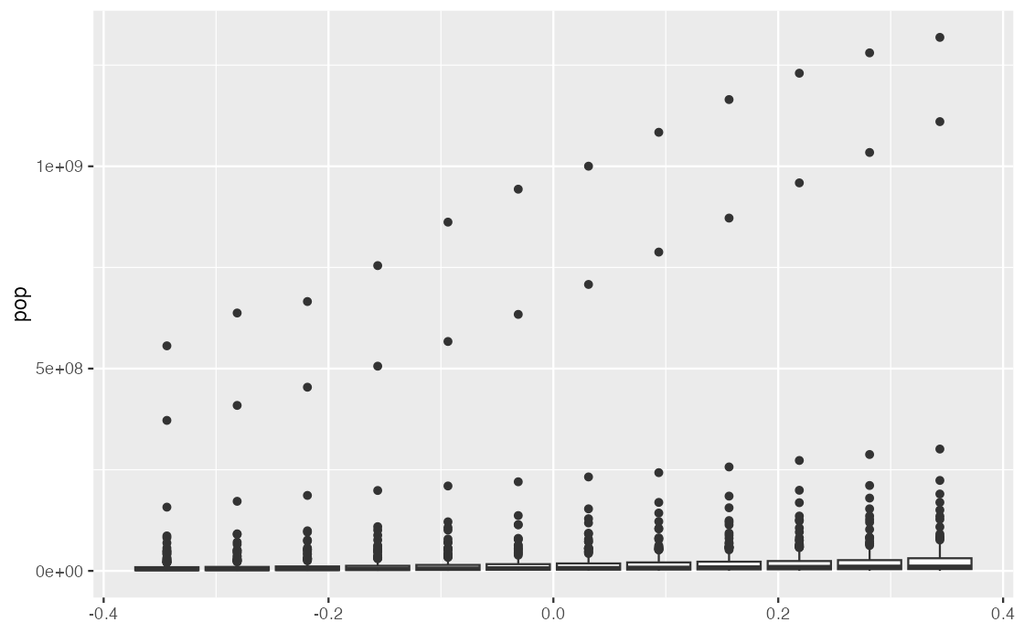

```r
ggplot(df, aes(y = pop, group = year)) + geom_boxplot()
```

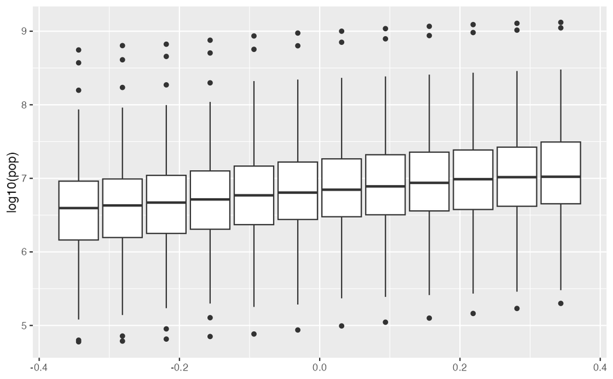

```r
ggplot(df, aes(y = log10(pop), group = year)) + geom_boxplot()
```

```r
p <- ggplot(df, aes(gdpPercap, lifeExp))
```

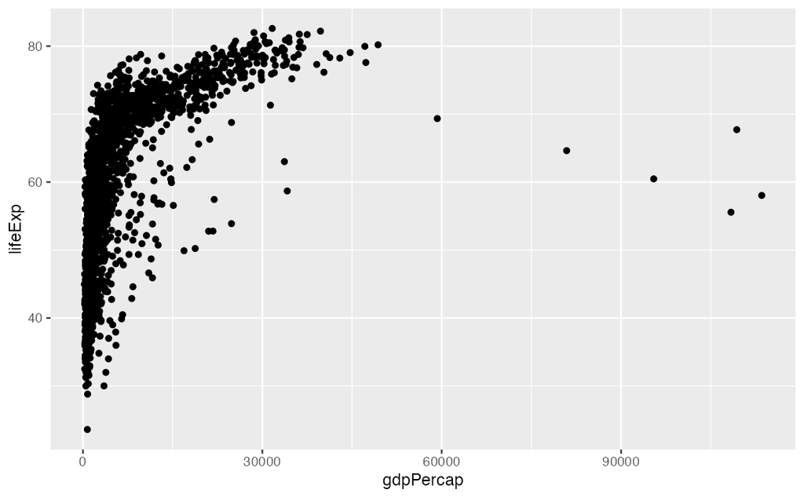

```r
p + geom_point()
```

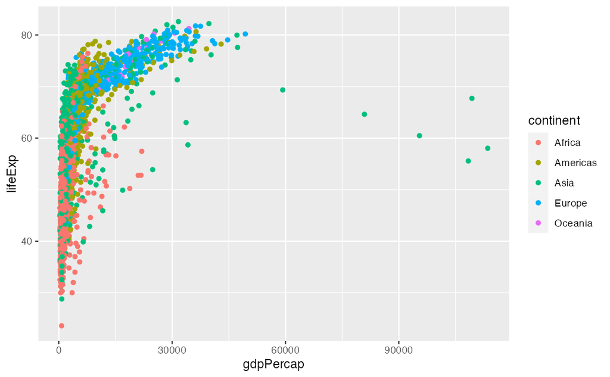

```r
p + geom_point(aes(color=continent))
```

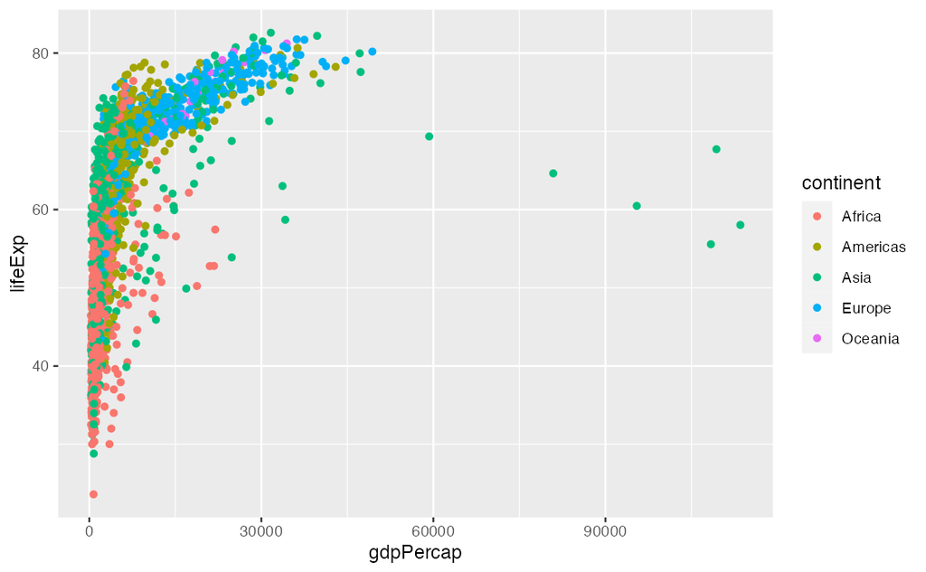

```r
df %>% ggplot(aes(gdpPercap, lifeExp, color = continent)) + geom_point()
```

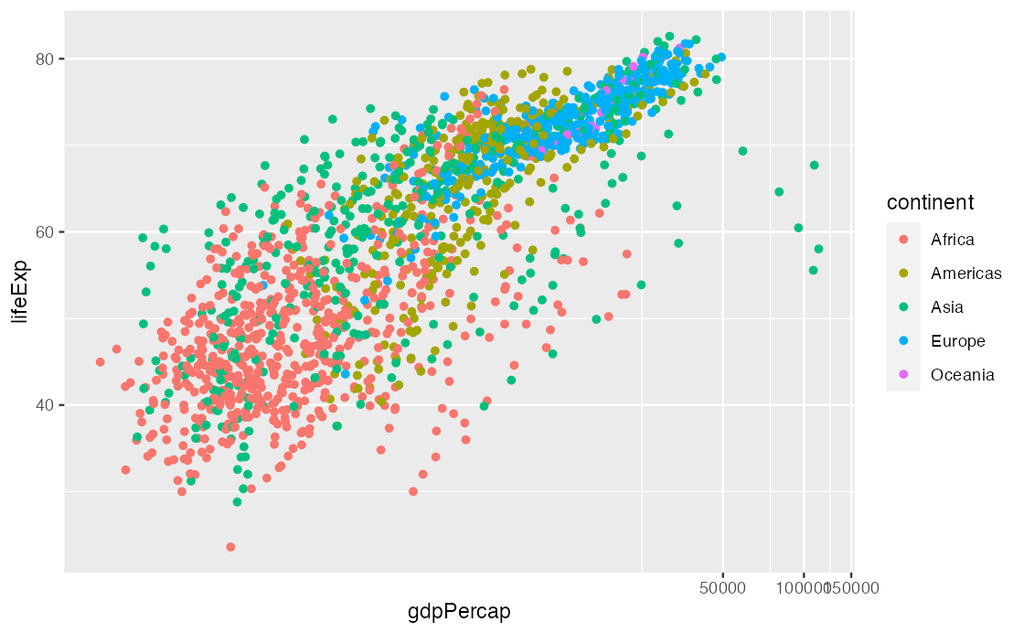

```r
df %>% ggplot(aes(gdpPercap, lifeExp, color = continent)) + geom_point() +
  coord_trans(x = "log10", y = "identity")
```

```r
df_lifeExp <- df %>% group_by(continent, year) %>%
  summarize(mean_lifeExp = mean(lifeExp), median_lifeExp = median(lifeExp), max_lifeExp = max(lifeExp), min_lifeExp = min(lifeExp))
```

```r
df_pop <- df %>% group_by(continent, year) %>%
  summarize(mean_pop = mean(pop), median_pop = median(pop), max_pop = max(pop), min_pop = min(pop))
```

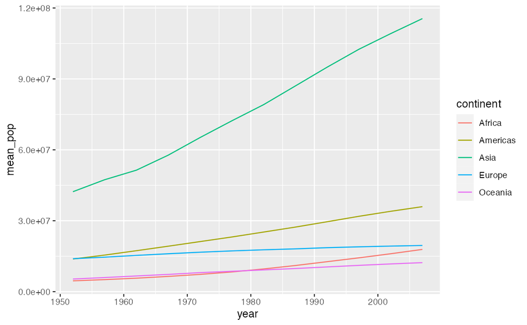

```r
df_pop %>% ggplot(aes(x = year, y = mean_pop, color = continent)) +
  geom_line()
```

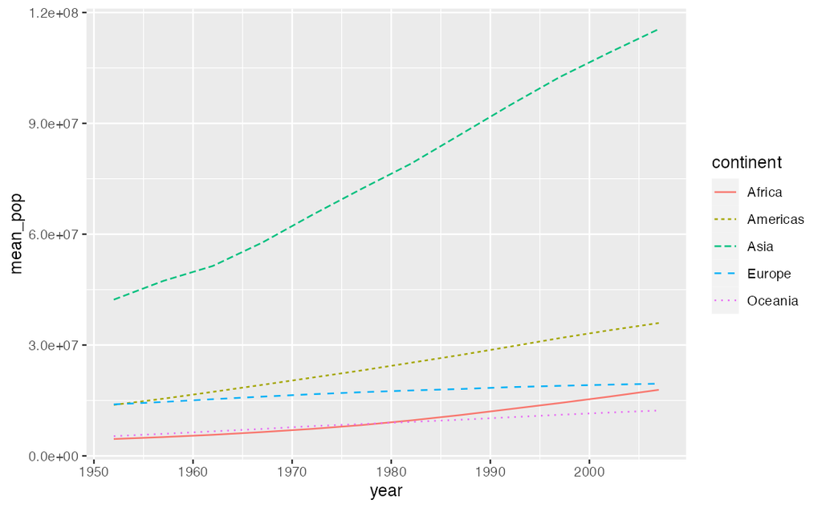

```r
df_pop %>% ggplot(aes(x = year, y = mean_pop, color = continent, linetype = continent)) +
  geom_line()
```

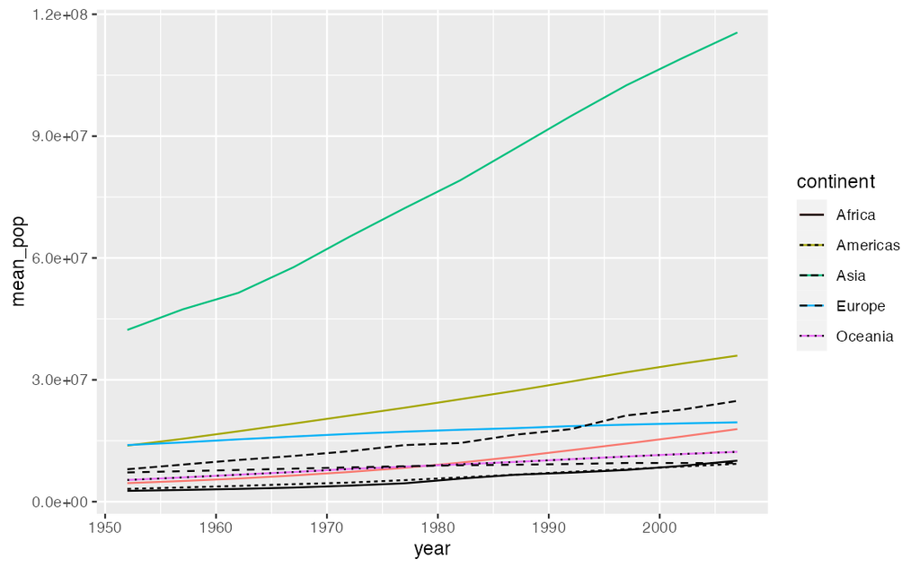

```r
df_pop %>% ggplot() +
  geom_line(aes(x = year, y = mean_pop, color = continent)) +
  geom_line(aes(x = year, y = median_pop, linetype = continent))
```

# Questions

## Q3.

```r
esoph
```

| agegp | alcgp | tobgp | ncases | ncontrols |
| --- | --- | --- | --- | --- |
| 25-34 | 0-39g/day | 0-9g/day | 0 | 40 |
| 25-34 | 0-39g/day | 10-19 | 0 | 10 |
| 25-34 | 0-39g/day | 20-29 | 0 | 6 |
| 25-34 | 0-39g/day | 30+ | 0 | 5 |
| 25-34 | 40-79 | 0-9g/day | 0 | 27 |
| 25-34 | 40-79 | 10-19 | 0 | 7 |
| 25-34 | 40-79 | 20-29 | 0 | 4 |
| 25-34 | 40-79 | 30+ | 0 | 7 |
| 25-34 | 80-119 | 0-9g/day | 0 | 2 |
| 25-34 | 80-119 | 10-19 | 0 | 1 |

[output cut: 78 more lines]

I wanted to include three variables in the first exercise to be able to compare tobacco consumption, number of cases of cancer, and age in the same graph but I was not able to do it.

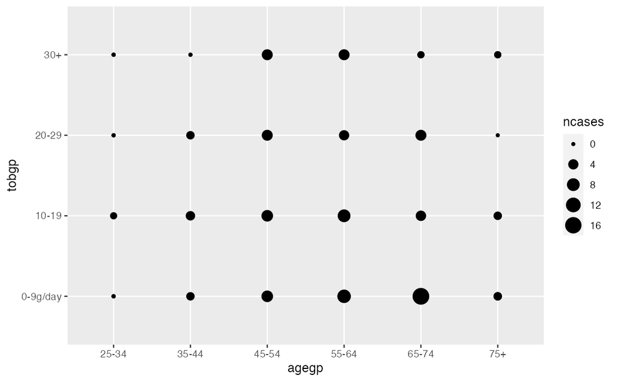

```r
ggplot(esoph) + geom_point(aes(agegp, tobgp, size=ncases))
```

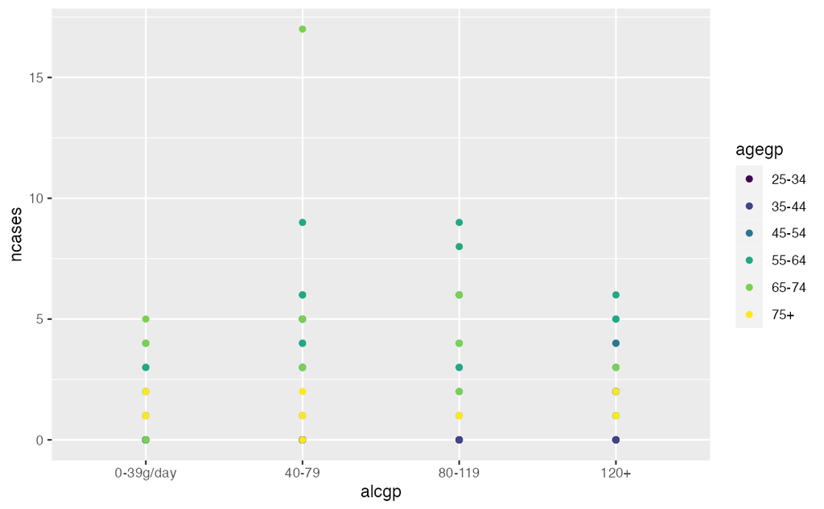

```r
ggplot(esoph, aes(x= alcgp, y=ncases, color=agegp))+geom_point()
```

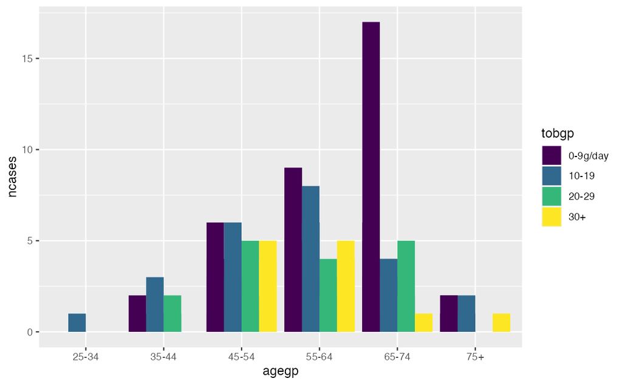

```r
ggplot(esoph, aes(x= agegp, y=ncases, fill = tobgp))+geom_col(position="dodge")
```

## Q1. Combine two charts

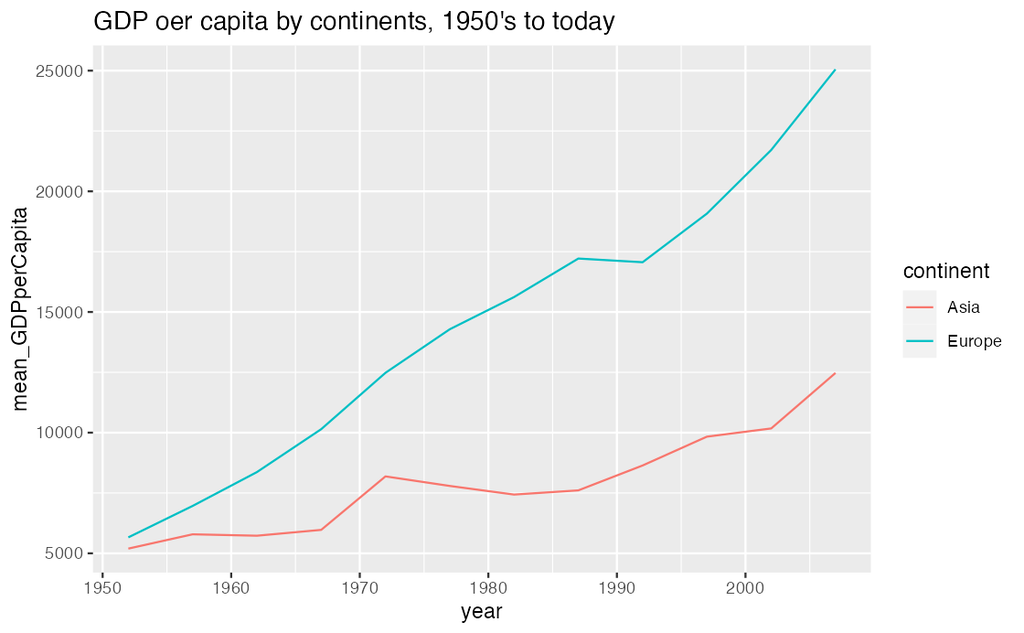

```r
df %>%
  select(country, continent, year, gdpPercap) %>%
  filter(continent %in% c("Asia", "Europe")) %>%
  group_by(continent, year) %>%
  summarise(mean_GDPperCapita = mean(gdpPercap)) %>%
  ggplot(aes(x=year)) +
  geom_line(aes(y=mean_GDPperCapita, color=continent)) +
  ggtitle("GDP oer capita by continents, 1950's to today")
```

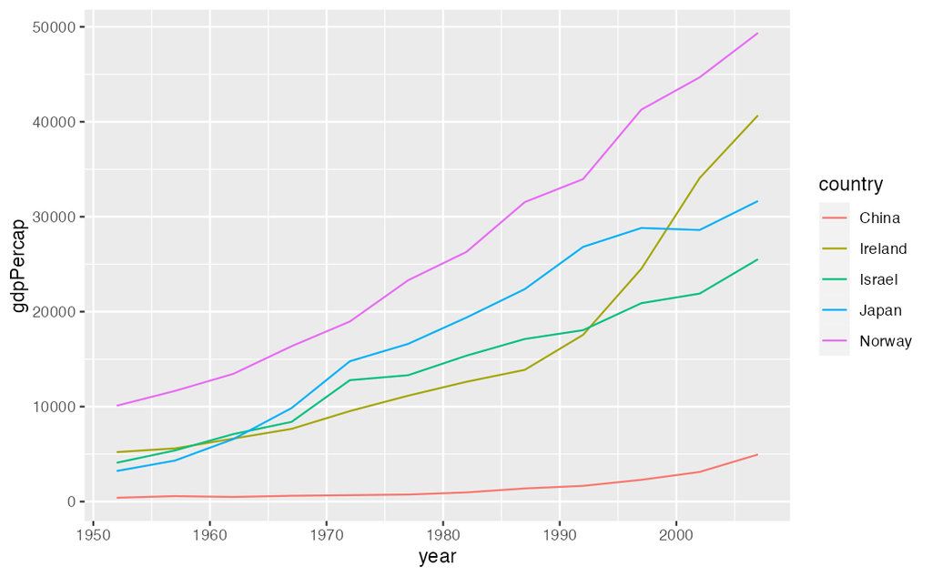

```r
df %>%
  select(country, year, gdpPercap) %>%
  filter(country %in% c("Israel", "Japan", "Norway", "China", "Ireland")) %>%
  ggplot(aes(x=year)) +
  geom_line(aes(y=gdpPercap, color=country))
```

**Question.** I have not managed to add on the same graph of the continents the data for the individual countries, as I would have liked:

**Solution.** Construct two datasets and add them one by one.

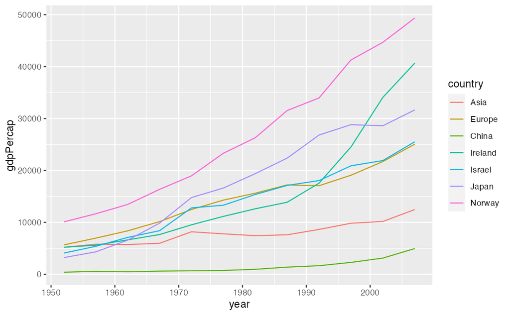

```r
df_2c <- df %>%
  select(continent, year, gdpPercap) %>%
  filter(continent %in% c("Asia", "Europe")) %>%
  group_by(continent, year) %>%
  summarise(gdpPercap = mean(gdpPercap), .groups = 'drop') %>%
  select(country = continent, year, gdpPercap)

df_5c <- df %>%
  select(country, year, gdpPercap) %>%
  filter(country %in% c("Israel", "Japan", "Norway", "China", "Ireland"))

df_2c %>% bind_rows(df_5c) %>%
  ggplot(aes(x = year, y = gdpPercap, color = country)) + geom_line()
```

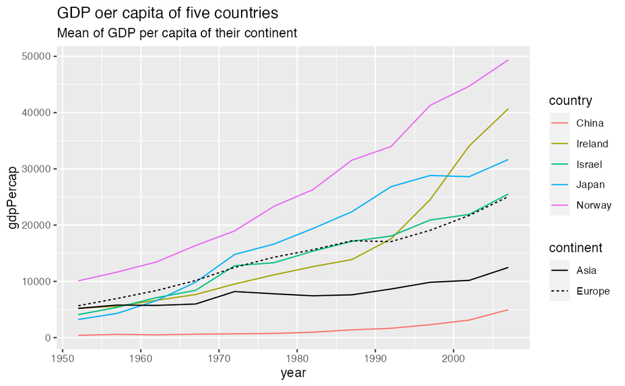

```r
df %>%
  group_by(continent, year) %>%
  mutate(mean_by_continent = mean(gdpPercap)) %>%
  ungroup() %>%
  filter(country %in% c("Israel", "Japan", "Norway", "China", "Ireland")) %>%
  ggplot(aes(x = year)) +
    geom_line(aes(y = gdpPercap, color=country)) +
    geom_line(aes(y = mean_by_continent, linetype=continent)) +
    labs(title = "GDP oer capita of five countries", subtitle = "Mean of GDP per capita of their continent")
```

When you want to change the linetype manually, use `scale_linetype_manual()`.

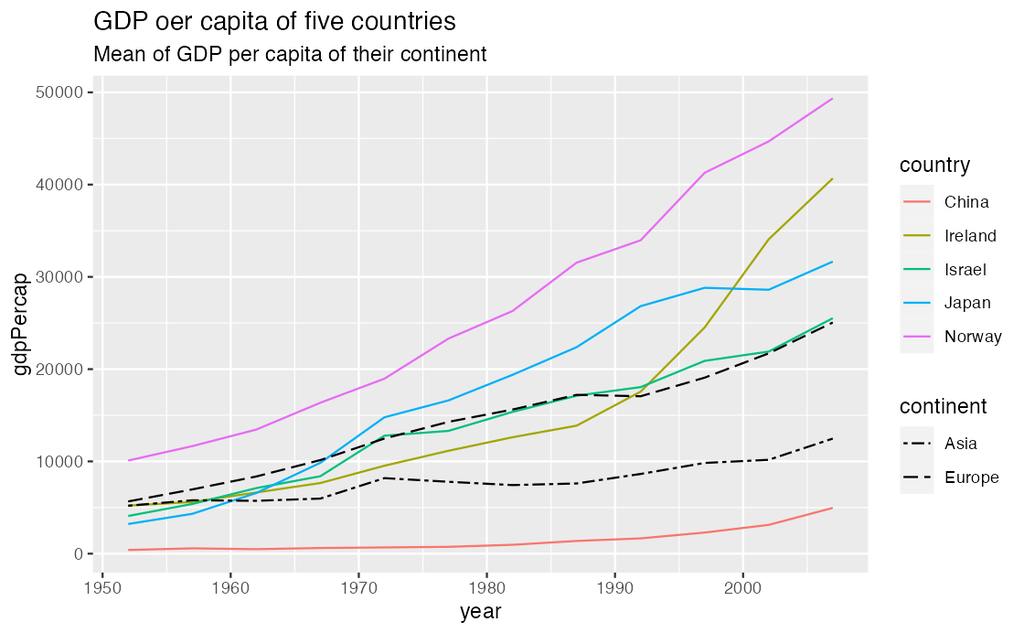

```r
df %>%
  group_by(continent, year) %>%
  mutate(mean_by_continent = mean(gdpPercap)) %>%
  ungroup() %>%
  filter(country %in% c("Israel", "Japan", "Norway", "China", "Ireland")) %>%
  ggplot(aes(x = year)) +
    geom_line(aes(y = gdpPercap, color=country)) +
    geom_line(aes(y = mean_by_continent, linetype=continent)) +
    scale_linetype_manual(values = c("Asia" = "twodash", "Europe" = "longdash")) +
    labs(title = "GDP oer capita of five countries", subtitle = "Mean of GDP per capita of their continent")
```

## Q2.

However, as the precise unit of data was not shown on the graph, for example, the unit for the age of orange trees, I had difficulties in finding the right unit to describe the data. Nonetheless, by looking at R database and using the ‘view’ command, I was able to figure out the details that were needed.

**Solutions** https://stat.ethz.ch/R-manual/R-devel/library/datasets/html/Orange.html